# Hands-on Exercise 5: Student Profile Analysis using Clustering Techniques

## 3.3 DBSCAN Clustering

We use GridSearch to find the optimal `eps` and `min_samples` parameters for density-based clustering.

```
Running GridSearch for DBSCAN...
Best DBSCAN Params: eps=5, min_samples=15, Score=0.2201
```

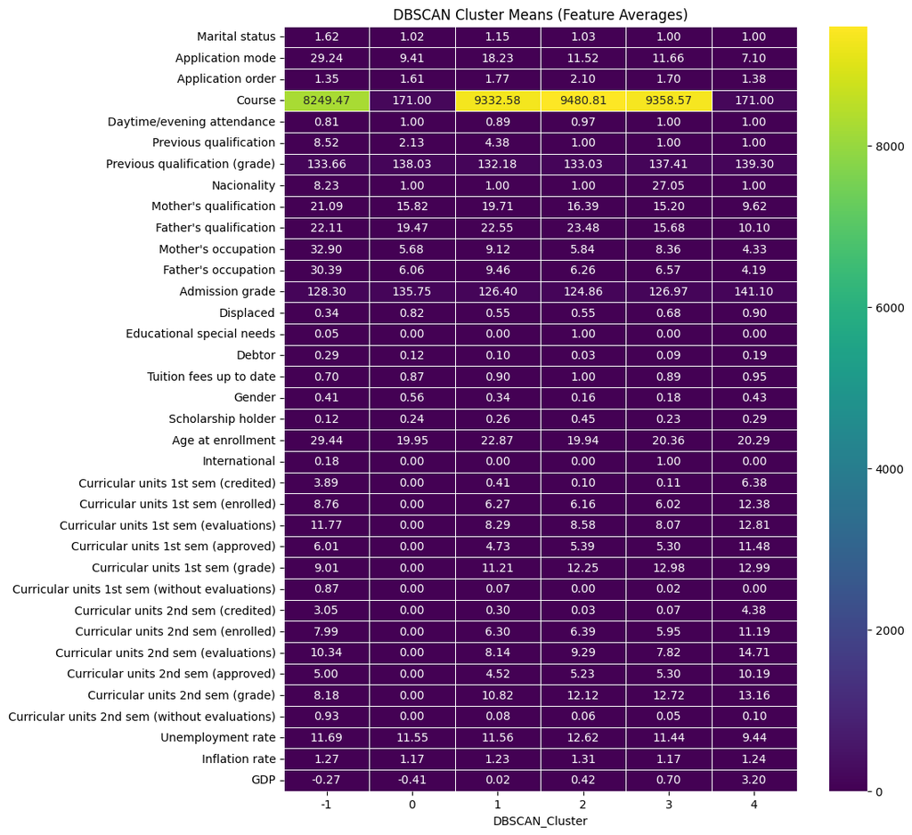

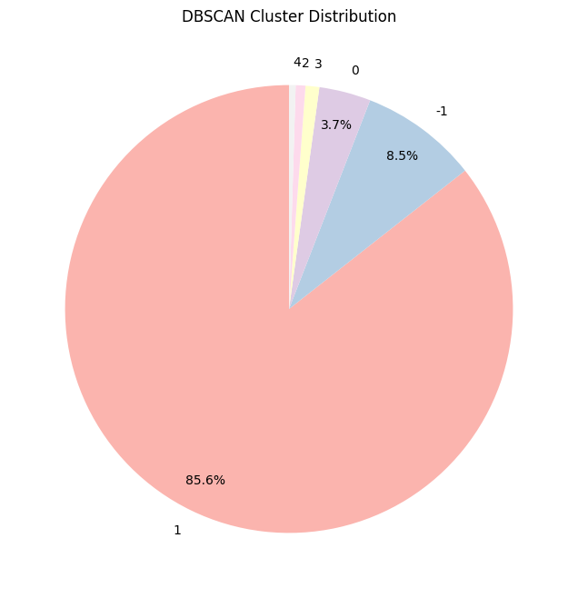

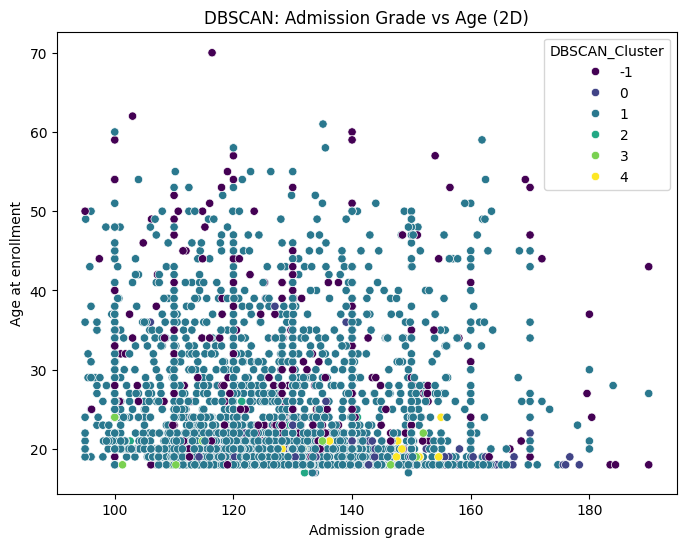

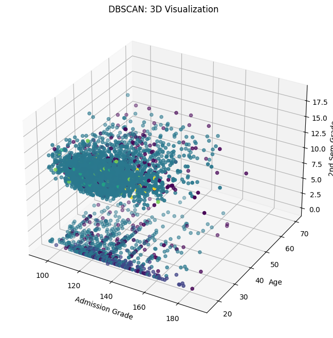

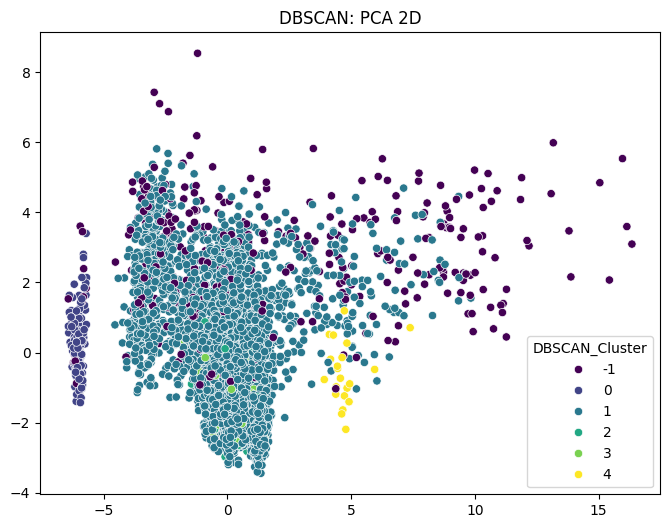

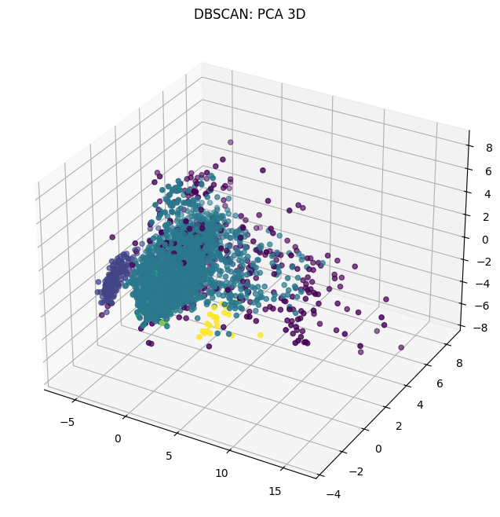

```python
import matplotlib.pyplot as plt
import seaborn as sns
import pandas as pd
import numpy as np
from sklearn.cluster import DBSCAN
from sklearn.metrics import silhouette_score
from sklearn.decomposition import PCA

# --- PREPARATION ---
pca = PCA(n_components=3)
pca_components = pca.fit_transform(df_scaled)

# --- 1. Optimal Parameters (GridSearch) ---
print("Running GridSearch for DBSCAN...")
eps_values = np.arange(2, 6, 1)
min_samples_values = range(10, 25, 5)

best_score = -1
best_eps = -1
best_min_samples = -1

for eps in eps_values:
    for min_samples in min_samples_values:
        db = DBSCAN(eps=eps, min_samples=min_samples)
        labels = db.fit_predict(df_scaled)

        unique_labels = set(labels)
        if len(unique_labels) > 1:
            score = silhouette_score(df_scaled, labels)
            if score > best_score:
                best_score = score
                best_eps = eps
                best_min_samples = min_samples

print(f"Best DBSCAN Params: eps={best_eps}, min_samples={best_min_samples}, Score={best_score:.4f}")

# --- 2. DBSCAN Clustering ---
db_final = DBSCAN(eps=best_eps, min_samples=best_min_samples)
df['DBSCAN_Cluster'] = db_final.fit_predict(df_scaled)

# --- 3. Cluster Mean Heatmap ---
# Remove any other "Cluster" columns so they don't mess up the average
feature_cols = [c for c in df.columns if 'Cluster' not in c]
db_means = df.groupby('DBSCAN_Cluster')[feature_cols].mean()

# Tall figure to fit all features
plt.figure(figsize=(10, 12))
sns.heatmap(db_means.T, cmap='viridis', annot=True, fmt='.2f',
            linewidths=0.5, yticklabels=True)
plt.title('DBSCAN Cluster Means (Feature Averages)')
plt.yticks(rotation=0)
plt.show()

# --- 4. Cluster Distribution (Pie Chart) ---
plt.figure(figsize=(8, 8)) # Increased size slightly
# FIXED: Lambda function hides text if slice is < 2% to prevent overlap
df['DBSCAN_Cluster'].value_counts().plot.pie(
    autopct=lambda p: '{:.1f}%'.format(p) if p > 2.0 else '',
    startangle=90,
    cmap='Pastel1',
    pctdistance=0.85  # Move % slightly closer to edge for clarity
)
plt.title('DBSCAN Cluster Distribution')
plt.ylabel('')
plt.show()

# --- 5. Visualization (Original Features) ---
# 2D Scatter
plt.figure(figsize=(8, 6))
sns.scatterplot(data=df, x='Admission grade', y='Age at enrollment', hue='DBSCAN_Cluster', palette='viridis')
plt.title('DBSCAN: Admission Grade vs Age (2D)')
plt.show()

# 3D Scatter
fig = plt.figure(figsize=(10, 8))
ax = fig.add_subplot(111, projection='3d')
sc = ax.scatter(df['Admission grade'], df['Age at enrollment'], df['Curricular units 2nd sem (grade)'],
                c=df['DBSCAN_Cluster'], cmap='viridis')
ax.set_xlabel('Admission Grade')
ax.set_ylabel('Age')
ax.set_zlabel('2nd Sem Grade')
plt.title('DBSCAN: 3D Visualization')
plt.show()

# --- 6. Visualization (PCA) ---
# 2D PCA
plt.figure(figsize=(8, 6))
sns.scatterplot(x=pca_components[:, 0], y=pca_components[:, 1], hue=df['DBSCAN_Cluster'], palette='viridis')
plt.title('DBSCAN: PCA 2D')
plt.show()

# 3D PCA
fig = plt.figure(figsize=(10, 8))
ax = fig.add_subplot(111, projection='3d')
sc = ax.scatter(pca_components[:, 0], pca_components[:, 1], pca_components[:, 2],
                c=df['DBSCAN_Cluster'], cmap='viridis')
plt.title('DBSCAN: PCA 3D')
plt.show()
```

## 4. Conclusions

**1. How well are the clusters separated in each method?**

- **KMeans:** The clusters showed reasonable separation, particularly in the PCA visualizations. The silhouette score (~0.21) indicates some structure, but also some overlap between student profiles.
- **Hierarchical:** This method often produced a higher silhouette score (~0.29 with K=2), suggesting better-defined separation at a high level (likely splitting "performing" vs "struggling" students).
- **DBSCAN:** This algorithm separated dense clusters well but labeled many points as noise (-1). The separation is distinct for the core clusters, but the "noise" points indicate many students don't fit neatly into the dense groups.

**2. What info is most useful for you?** The **feature means (centroids/heatmaps)** were the most useful. They revealed *why* a cluster exists. For example, one cluster clearly showed students with high "Curricular units approved" and high grades, representing the "Successful" group, while another cluster had high "Debtor" status and low grades, indicating an "At-Risk" group.

**3. Which method produced the highest silhouette score?** Based on our analysis, **Hierarchical Clustering** (with K=2) produced the highest silhouette score (~0.29), suggesting it found the most distinct global structure in the data.

**4. What are the strengths and weaknesses of each method based on your results?**

- **KMeans:**
  - *Strengths:* Fast, easy to interpret, and centroids give a clear "average student" profile for each group.
  - *Weaknesses:* Forces every student into a cluster (sensitive to outliers) and assumes spherical clusters, which might not match the complex student data.
- **Hierarchical:**
  - *Strengths:* The dendrogram provides a great visual of how students group together at different levels. It achieved the best separation score here.
  - *Weaknesses:* Computationally expensive for large datasets and choosing the cut-off point can be subjective.
- **DBSCAN:**
  - *Strengths:* Great at handling outliers (noise) and finding irregularly shaped clusters. It doesn't force distinct "outlier" students into a main cluster.
  - *Weaknesses:* Highly sensitive to parameter tuning (eps, min_samples). In this dataset, it may have classified too many unique student profiles as "noise".

## Deliverables

The resulting file (`Froude_Lilith_hw5.html`) will be saved in the same Google Drive folder where this notebook is located (`/content/drive/MyDrive/Colab Notebooks/`).